# Notebook

### Plotting in Base R

Let's create some basic plots, now in R. We're not going to be using the powerful ggplot2 yet. Let's stick with default R for the time being.

```python
#Load the R Magic so we can execute R scripts within this notebook
%load_ext rmagic
```

**Line Charts**

```python
%%R -i cars -w 800 -h 380 -u px
#Pass and receive dataframe from Python to R
cars<-data.frame(cars)
```

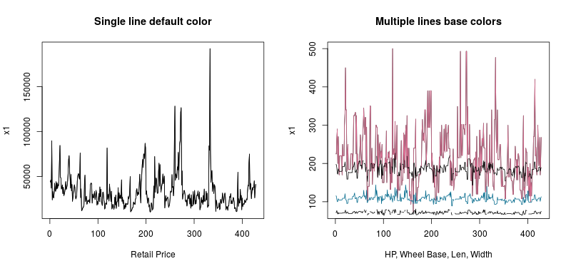

```python
%%R -w 800 -h 380 -u px
mat<-layout(matrix(c(1,2),1,2))
plot(cars['Retail.Price'], type='l', main='Single line default color', xlab='Retail Price')
lines(cars['Retail.Price'])
plot(cars['HP'], type='l',main='Multiple lines base colors',xlab='HP, Wheel Base, Len, Width')
lines(cars['HP'], col='palevioletred')
lines(cars['Wheel.Base'], col='deepskyblue4')
lines(cars['Len'], color='paleturquoise4')
lines(cars['Width'], color='firebrick')
#legend('topright', inset=c(-.2,0),legend=c('HP','Wheel Base', 'Len', 'Width'),
#       col=c('palevioletred','deepskyblue4','paleturquoise4','firebrick'),xpd=TRUE)
```

Few interesting things to note there.

Note the lack of a legend and ugly use of labels in the x axis. That's partly my fault as I chose to put it there but the lack of legend is due to IPython and R not playing well together. If you try to move the legend outside the plot (it's too big to be inside) IPython will truncate it since we fix the plot size going in.

You can see the command to display legend though in the commented line. Let's finish up and look at scatter and bar plots as well.

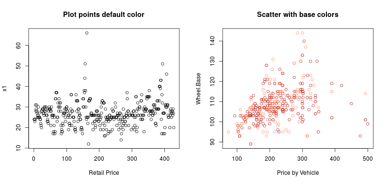

```python
%%R -w 800 -h 380 -u px
#Pass and receive dataframe from Python to R
mat<-layout(matrix(c(1,2),1,2))
plot(cars['Hwy.MPG'], main='Plot points default color', xlab='Retail Price')
plot(cbind(cars['HP'], cars['Wheel.Base']), main='Scatter with base colors',xlab='Price by Vehicle',
         col=c('firebrick','salmon1'))
```

Again, R plots look more beautiful yet easy on the eye. It's the colors that make a huge difference here. Also note that the second scatter plot wasn't colored based on anything specific. I love the way we code labels in Python when the system wonderfully uses the colors to contrast different values, by default. We can do the same thing in R, its just a bit more involved.

R has other advantages too though. It automatically adjustd chart types based on the data we're plotting. For instance, if I chose to display the Highway MPG by Brand, R will automatically change the plot type to a mixed box and scatter plot.

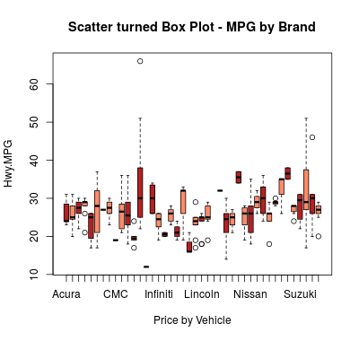

```python
%%R -w 400 -h 380 -u px
#Pass and receive dataframe from Python to R
plot(cbind(cars['Brand'], cars['Hwy.MPG']), main='Scatter turned Box Plot - MPG by Brand',xlab='Price by Vehicle',
         col=c('firebrick','salmon1'))
```

Let's wrap things up by looking at Histo and Bar.

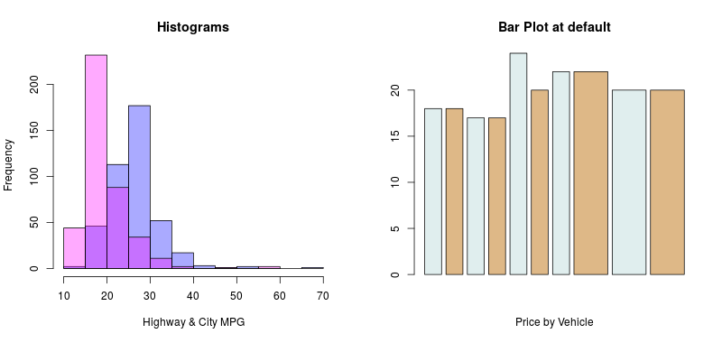

```python
%%R -w 800 -h 380 -u px
#Pass and receive dataframe from Python to R
mat<-layout(matrix(c(1,2),1,2))
hist(as.numeric(unlist(cars['Hwy.MPG'])), col=rgb(0,0,1,1/3), main='Histograms', ylim=c(0,225), xlab="Highway & City MPG")
hist(as.numeric(unlist(cars['City.MPG'])), col=rgb(1,0,1,1/3), add=T)
barplot(as.matrix(as.numeric(unlist(cars['City.MPG'])))[1:10],  as.numeric(unlist(cars['Brand']))[1:10],
        main='Bar Plot at default',xlab='Price by Vehicle',
        col=c('azure2','burlywood'), alpha=0.5)
```

In our brief tour of base graphics with R, we already see that the defaults in matplotlib aren't anywhere close aesthetically to the results in R. Although there is much more than just aesthetics to a visualization. The beauty of R is not its base graphics package but the awesome ggplot2.

We will explore the ggplot2 package in the next post.

Happy Reading!